# Replikacja efektu Knobe’a na polskich przysłówkach - raport z badania

## Autorzy badania: Katarzyna Kuś, Bartosz Maćkiewicz

## Cel badania:

Replikacja efektu Knobe (Knobe, 2003) na polskich przysłówkach.

## Konstrukcja badania:

Badanie było replikacją oryginalnego badania J. Knobe’a. W języku polskim angielskiemu terminowi “intentionally”, użytemu przez Knobe’a odowiada cała klasa bliskoznacznych wyrażeń. Do badania wyobraliśmy następujące przysłówki i wyrażenia czasownikowe:

- Specjalnie
- Świadomie
- Celowo
- Umyślnie
- Z rozmysłem
- Chciał
- Zamierzał

Przeprowadziliśmy również modyfikację badania Knobe’a, w którym w miejscu “intentionally” nie pojawiło się żadne wyrażenie.

Każdemu z badanych zaprezentowana był jeden z dwóch scenariuszy, w których w miejscu oznaczonym [i-modyfikator] stał odpowiedni przysłówek lub inne wyrażenie, wskazujące na intencjonalność działania :

**Scenariusz HARM**

Wicedyrektor zwraca się do dyrektora pewnej firmy:

„Myślimy o wdrożeniu nowego programu. Pozwoli nam zwiększyć zyski, ale zaszkodzi środowisku”.

Dyrektor odpowiada:

„Nie obchodzi mnie szkodzenie środowisku. Chcę tylko zwiększyć zyski. Wdrażamy program”.

Program został wdrożony i rzeczywiście zaszkodził środowisku.

Czy dyrektor [i-modyfikator] zaszkodził środowisku?

**Scenariusz HELP**

Wicedyrektor zwraca się do dyrektora pewnej firmy:

„Myślimy o wdrożeniu nowego programu. Pozwoli nam zwiększyć zyski i pomoże środowisku”.

Dyrektor odpowiada:

„Nie obchodzi mnie pomaganie środowisku. Chcę tylko zwiększyć zyski. Wdrażamy program”.

Program został wdrożony i rzeczywiście pomógł środowisku.

Czy dyrektor [i-modyfikator] pomógł środowisku?

Przeprowadziliśmy również badanie na dwóch wyrażeniach: “z rozmysłem” oraz “umyślnie”, w których badani konfrontowani byli ze zmienionymi scenariuszami. Zamiana ta polegała na usunięciu fragmentu wypowiedzi dyrektora: *Nie obchodzi mnie pomaganie środowisku. Chcę tylko zwiększyć zyski*. Eksperyment miał na celu rozstrzygnięcie na ile wysokie wystąpienie efektu Knobe’a w badaniu z wyrażeniem “z rozmysłem” związane jest z tym, że konotuje ono pewną deliberację i nie jest czystym i-modyfikatorem.

## Technikalia

Każdemu z badanych zaprezentowany był tylko jeden scenariusz. Czas na odpowiedź był nieograniczony. Badanie odbyło się za pośrednictwem internetowego systemu ankietowego Limesurvey na platformie uniwersyteckiej Kognilab.

## Wyniki:

### Specjalnie:

```
##         GROUP
## RESPONSE Harm Help
##      0      5    0
##      Nie   35   74
##      Tak   40    6
```

#### Test istotności statystycznej:

```
##
##  Pearson's Chi-squared test with Yates' continuity correction
##
## data:  GROUP and RESPONSE
## X-squared = 36.799, df = 1, p-value = 1.31e-09
```

#### Wykres:

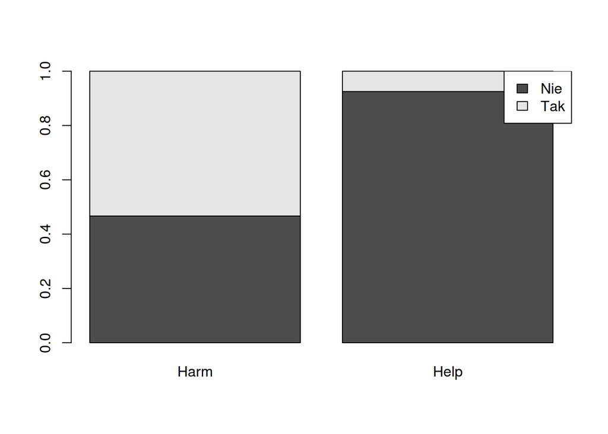

### Świadomie

```
##         GROUP
## RESPONSE Harm Help
##      0      5    4
##      Nie    7   32
##      Tak   62   35
```

#### Test istotności statystycznej:

```
##
##  Pearson's Chi-squared test with Yates' continuity correction
##
## data:  GROUP and RESPONSE
## X-squared = 21.714, df = 1, p-value = 3.165e-06
```

#### Wykres:

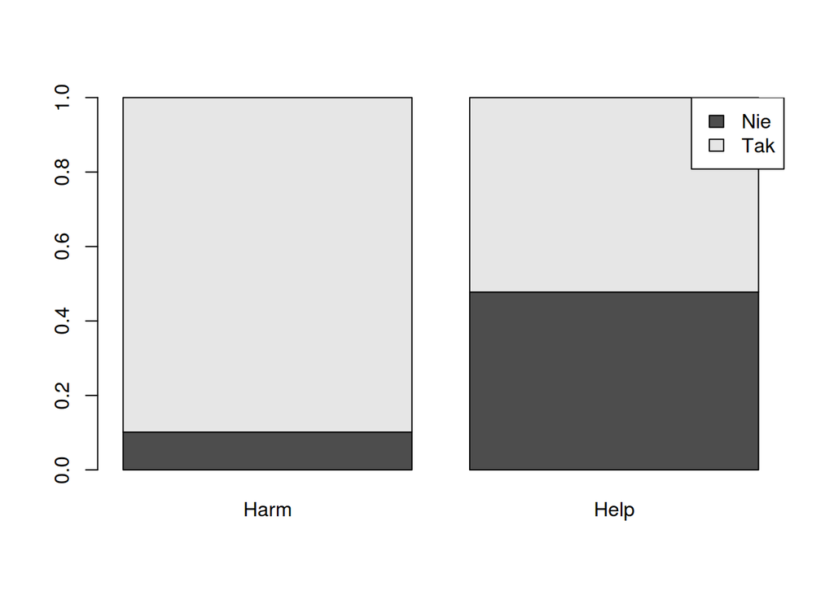

### Celowo

```
##         GROUP
## RESPONSE Harm Help
##      0      9    5
##      Nie   37   69
##      Tak   37    9
```

#### Test istotności statystycznej:

```
##
##  Pearson's Chi-squared test with Yates' continuity correction
##
## data:  GROUP and RESPONSE
## X-squared = 24.826, df = 1, p-value = 6.275e-07
```

#### Wykres:

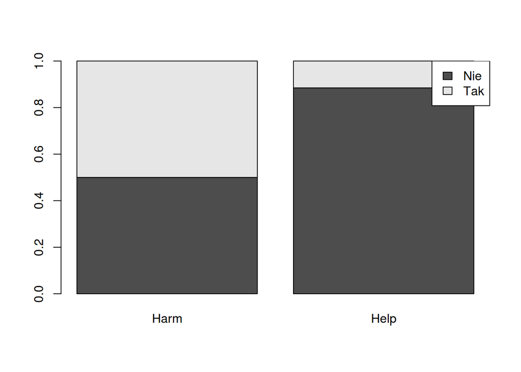

### Z rozmysłem

```
##         GROUP
## RESPONSE Harm Help
##      0      7    1
##      Nie    9   60
##      Tak   48    4
```

#### Test istotności statystycznej:

```
##
##  Pearson's Chi-squared test with Yates' continuity correction
##
## data:  GROUP and RESPONSE
## X-squared = 71.624, df = 1, p-value < 2.2e-16
```

#### Wykres:

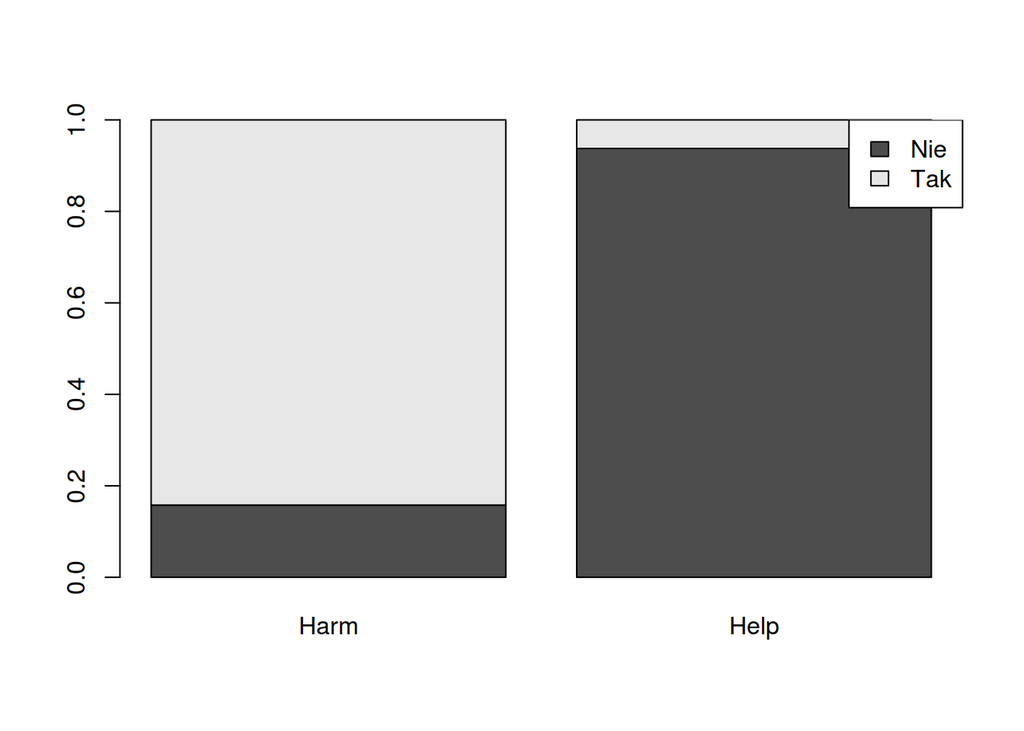

### Umyślnie

```
##         GROUP
## RESPONSE Harm Help
##      0      4    8
##      Nie   15   56
##      Tak   59   13
```

#### Test istotności statystycznej:

```
##
##  Pearson's Chi-squared test with Yates' continuity correction
##
## data:  GROUP and RESPONSE
## X-squared = 50.547, df = 1, p-value = 1.163e-12
```

#### Wykres:

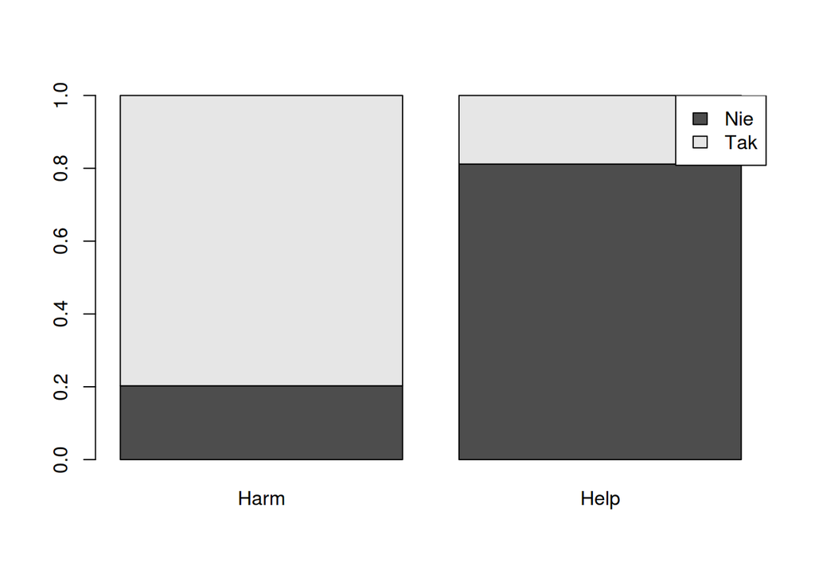

### Brak przysłówka

```
##         GROUP
## RESPONSE Harm Help
##      0      7    1
##      Nie    5   17
##      Tak   65   58
```

#### Test istotności statystycznej:

```
##
##  Pearson's Chi-squared test with Yates' continuity correction
##
## data:  GROUP and RESPONSE
## X-squared = 5.627, df = 1, p-value = 0.01769
```

#### Wykres:

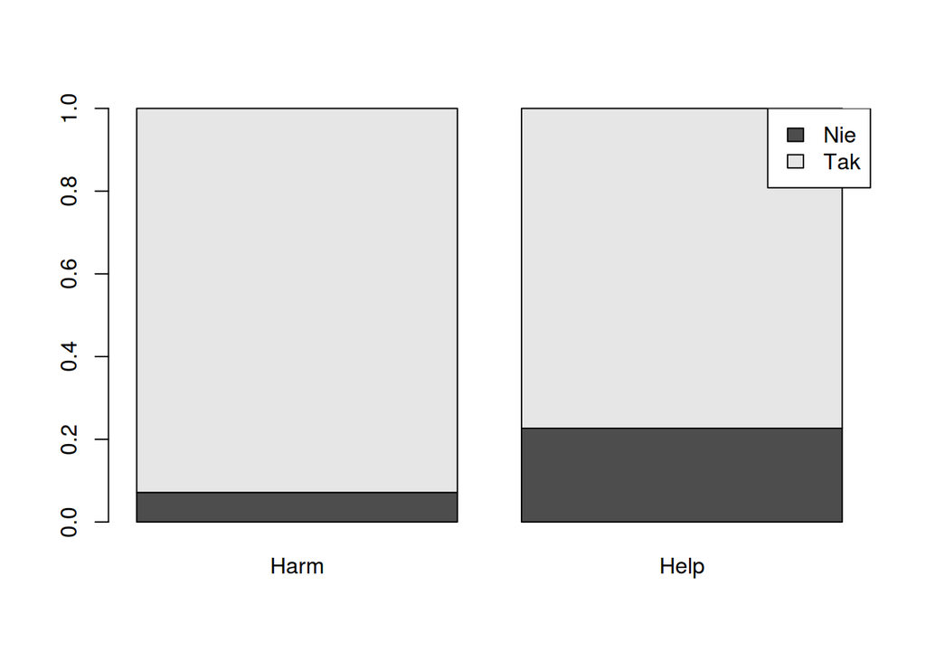

### Umyślnie w scenariuszach bez deliberacji

[output not shown]

#### Test istotności statystycznej:

[output not shown]

#### Wykres:

[figure not shown]

### Z rozmysłem w scenariuszach bez deliberacji

[output not shown]

#### Test istotności statystycznej:

[output not shown]

#### Wykres:

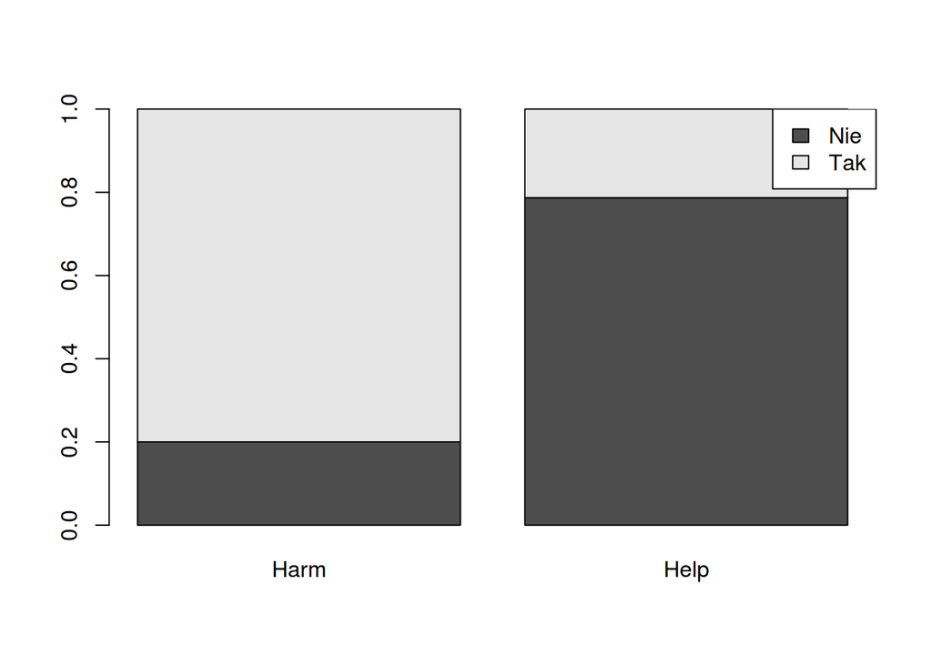

## Tabela zbiorcza:

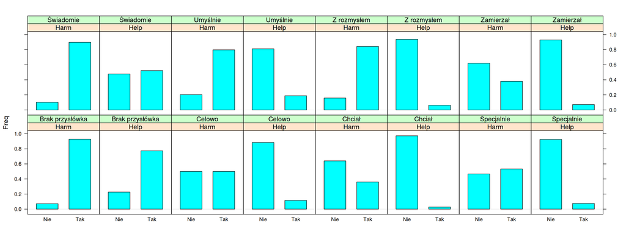